# Multimorbidity

# 1 Description of DataSchema variable

The description of harmonised variable is the following:

- Short name: `multimorbid`
- Variable label: `Multimorbidity status`
- Variable description:
  - `Since many of the datasets in ATHLOS do not have information about disease severity, we opted for a simple disease count as a measure of multimorbidity. This is the most common multimorbidity operational definition/measure (Huntley et al, 2012).`
  - `We used the harmonised disease variables in ATHLOS harmonised datasets. These included: diabetes, asthma, chronic pulmonary disease, hypertension, arthritis, angina, myocardial infarction and stroke. Each disease was coded as a dichotomous variable where yes (presence) = 1 and no (absence) = 0.`
  - `Multimorbid_score is the sum of all scores given to the diseases. If multimorbid_score > = 2, then the respondent is deemed to have multimorbidity, and their multimorbid_status is coded 1. Otherwise, if multimorbid_score < 2, then the respondent is deemed to not have multimorbidity and their multimorbid_status is coded 0.`
- Domain: `Diseases`
- Value type: `categorical`
- Category coding:

| **Code** | **Category Label** |
| --- | --- |
| 0 | No |
| 1 | Yes |

- Category missings:

| **Code** | **Category Label** |
| --- | --- |
| 991 | CAPI/interviewer error |
| 992 | Impute |
| 993 | Disable to measure |
| 994 | Not attempt/not done |
| 995 | Does not answer |
| 996 | Not applicable |
| 997 | Refuse |
| 998 | Do not know |
| 999 | Missing |

# 2 Data process

## 2.1 England

### 2.1.1 Wave 1

#### 2.1.1.1 Study-specific variable description

| **Name** | `h_diabetes` | `h_asthma` | `h_hypertension` | `h_joint_disorders` | `h_cpd` | `stroke` | `mi_ha` | `h_angina` |
| --- | --- | --- | --- | --- | --- | --- | --- | --- |
| **Label** | `History of diabetes mellitus` | `History of asthma` | `History of hypertension` | `History of arthritis, rheumatism or osteoarthritis` | `History of chronic pulmonary disorders` | `Stroke` | `Myocardial infarction or heart attack` | `History of angina` |
| **Table name** | `elsa_w1_hd` | `elsa_w1_hd` | `elsa_w1_hd` | `elsa_w1_hd` | `elsa_w1_hd` | `elsa_w1_hd` | `elsa_w1_hd` | `elsa_w1_hd` |
| **Categories** | `0 = No` `1 = Yes` | `0 = No` `1 = Yes` | `0 = No` `1 = Yes` | `0 = No` `1 = Yes` | `0 = No` `1 = Yes` | `0 = No` `1 = Yes` | `0 = No` `1 = Yes` | `0 = No` `1 = Yes` |
| **Missings** | `996 = Not applicable` `997 = Refuse` `998 = Do not know` `999 = Missing` | `996 = Not applicable` `997 = Refuse` `998 = Do not know` `999 = Missing` | `996 = Not applicable` `997 = Refuse` `998 = Do not know` `999 = Missing` | `996 = Not applicable` `997 = Refuse` `998 = Do not know` `999 = Missing` | `996 = Not applicable` `997 = Refuse` `998 = Do not know` `999 = Missing` | `996 = Not applicable` `997 = Refuse` `998 = Do not know` `999 = Missing` | `996 = Not applicable` `997 = Refuse` `998 = Do not know` `999 = Missing` | `996 = Not applicable` `997 = Refuse` `998 = Do not know` `999 = Missing` |
| **Description** |  |  |  |  |  |  |  |  |

h_diabetes

| Sample size | Missing values |
| --- | --- |
| 12099 | 9 |

Category

|  | 0 | 1 |
| --- | --- | --- |
| Frequency | 11224.00 | 866.00 |
| Percentage | 92.77 | 7.16 |

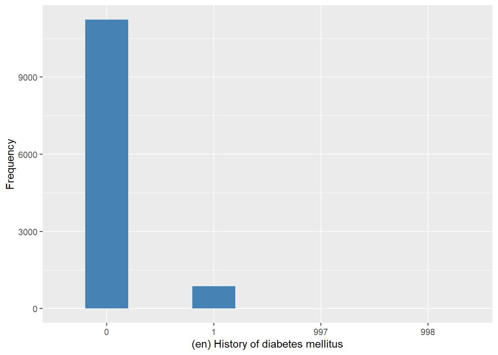

h_asthma

| Sample size | Missing values |
| --- | --- |
| 12099 | 10 |

Category

|  | 0 | 1 |
| --- | --- | --- |
| Frequency | 10672.00 | 1417.00 |
| Percentage | 88.21 | 11.71 |

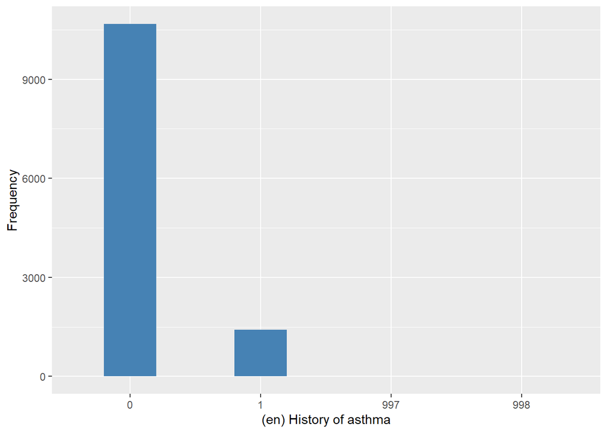

h_hypertension

| Sample size | Missing values |
| --- | --- |
| 12099 | 9 |

Category

|  | 0 | 1 |
| --- | --- | --- |
| Frequency | 7616.00 | 4474.00 |
| Percentage | 62.95 | 36.98 |

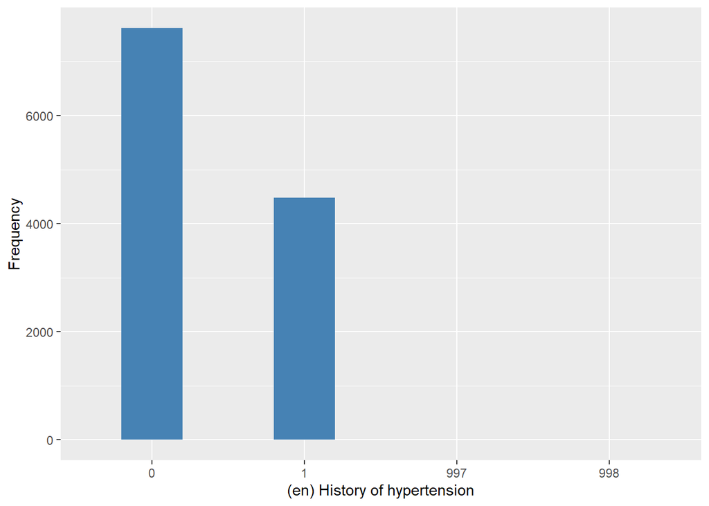

h_joint_disorders

| Sample size | Missing values |
| --- | --- |
| 12099 | 10 |

Category

|  | 0 | 1 |
| --- | --- | --- |
| Frequency | 8279.00 | 3810.00 |
| Percentage | 68.43 | 31.49 |

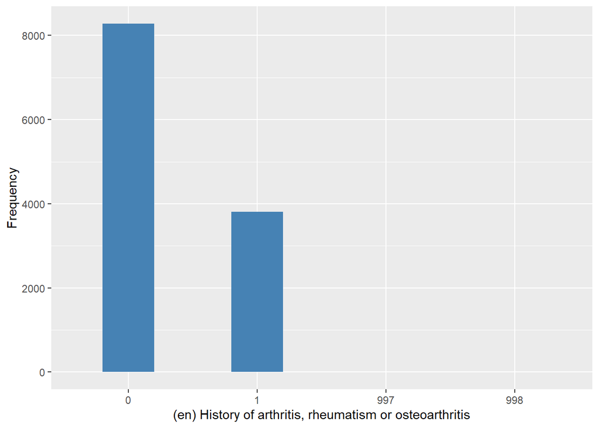

h_cpd

| Sample size | Missing values |
| --- | --- |
| 12099 | 10 |

Category

|  | 0 | 1 |
| --- | --- | --- |
| Frequency | 11326.00 | 763.00 |
| Percentage | 93.61 | 6.31 |

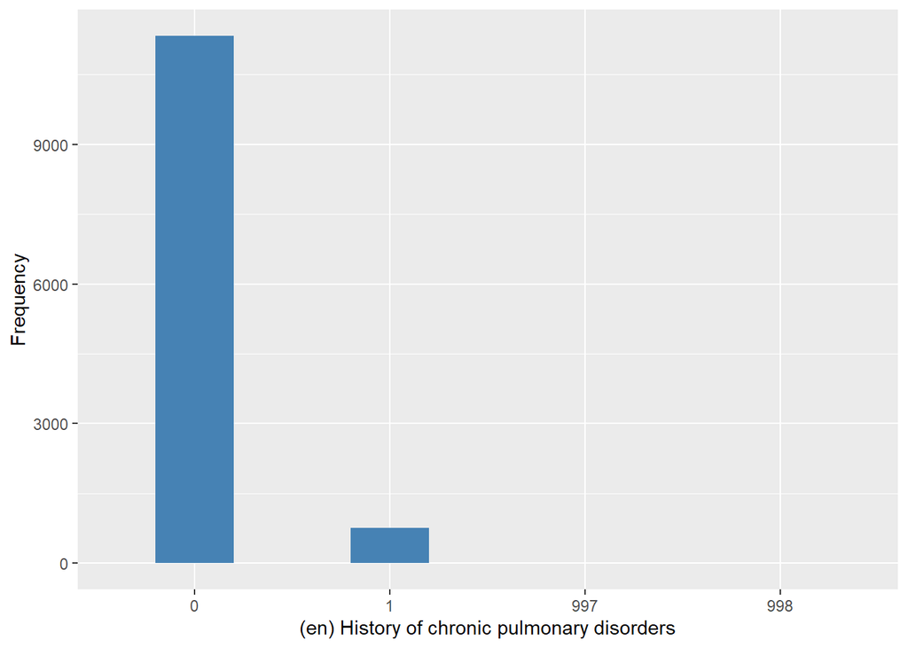

stroke

| Sample size | Missing values |
| --- | --- |
| 12099 | 9 |

Category

|  | 0 | 1 |
| --- | --- | --- |
| Frequency | 11574.00 | 516.00 |
| Percentage | 95.66 | 4.26 |

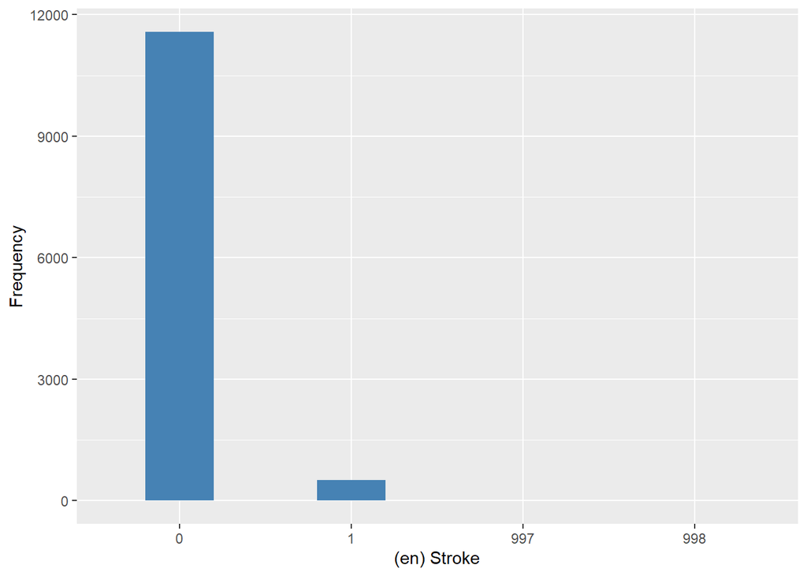

mi_ha

| Sample size | Missing values |
| --- | --- |
| 12099 | 9 |

Category

|  | 0 | 1 |
| --- | --- | --- |
| Frequency | 11388.00 | 702.0 |
| Percentage | 94.12 | 5.8 |

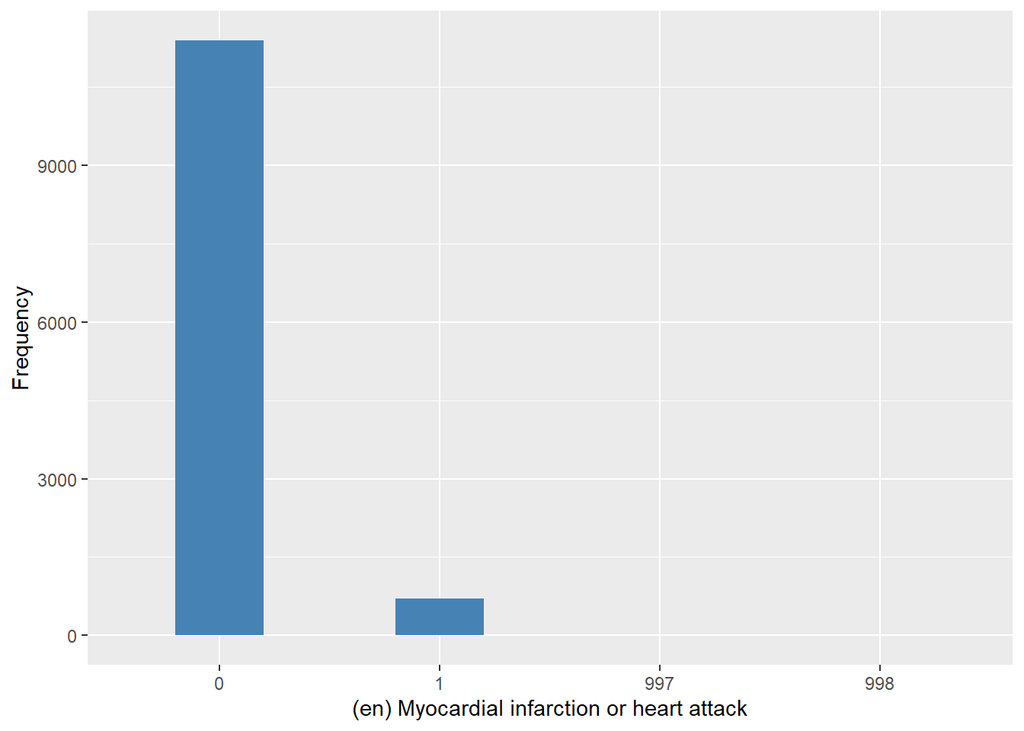

h_angina

| Sample size | Missing values |
| --- | --- |
| 12099 | 9 |

Category

|  | 0 | 1 |
| --- | --- | --- |
| Frequency | 10943.00 | 1147.00 |
| Percentage | 90.45 | 9.48 |

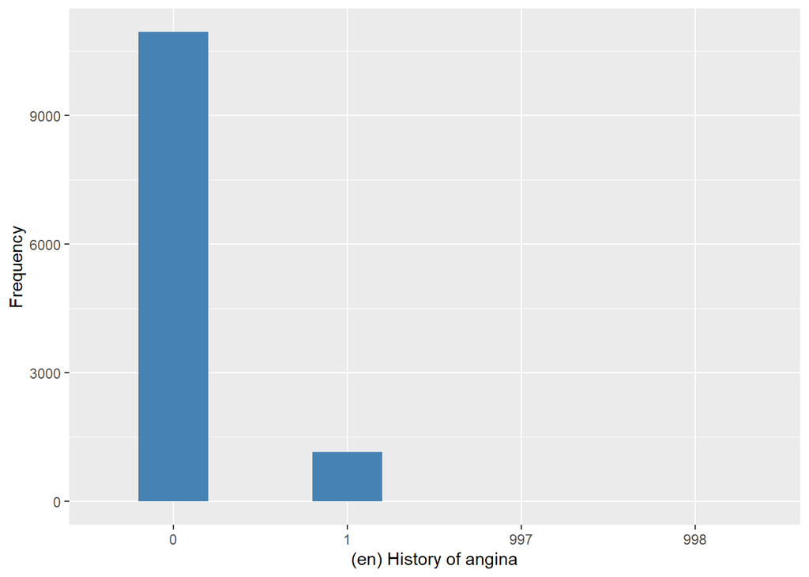

#### 2.1.1.2 Harmonisation algorithm

To compute `multimorbid` from the study-specific variables they have to be recoded as follows:

- `Multimorbid_score = sum(h_diabetes, h_asthma, h_hypertension, h_angina, mi_ha, h_joint_disorders, stroke, h_cpd)`
- `Multimorbid_status = 1 if multimorbid_score > = 2`
- `Multimorbid_status = 0 if multimorbid_score < 2`
- `otherwise into 999`

**R script:**

```r
ELSA_ds_w1 <- ELSA_w1 %>% mutate(dead = purrr::pmap(mutate_at(., vars(-id),
    `==`, 996) %>% select(., -id), all) %>% unlist()) %>% mutate_at(names(ELSA_w1[,
    -1]), ~replace(., list = which(. %in% 991:999), values = NA)) %>% mutate(multimorbid_score = rowSums(select(.,
    -1, -dead), na.rm = T)) %>% mutate(cardNA = rowSums(!is.na(select(., -1,
    -dead, -multimorbid_score)))) %>% mutate(cardNA = cardNA/cardNA) %>% mutate(multimorbid_score = multimorbid_score *
    cardNA) %>% mutate(multimorbid = case_when(multimorbid_score >= 2 ~ 1, multimorbid_score <
    2 ~ 0, dead ~ 996, TRUE ~ 999)) %>% select(id, multimorbid)
```

#### 2.1.1.3 Statistics of the new harmonized variable

Multimorbidity status

| Sample size | Missing values |
| --- | --- |
| 12099 | 7 |

Category

|  | 0 | 1 |
| --- | --- | --- |
| Frequency | 8334.00 | 3758.00 |
| Percentage | 68.88 | 31.06 |

Type of missing

|  | 991 | 992 | 993 | 994 | 995 | 996 | 997 | 998 | 999 | NA |
| --- | --- | --- | --- | --- | --- | --- | --- | --- | --- | --- |
| Frequency | 0 | 0 | 0 | 0 | 0 | 0 | 0 | 0 | 7.00 | 0 |
| Percentage | 0 | 0 | 0 | 0 | 0 | 0 | 0 | 0 | 0.06 | 0 |

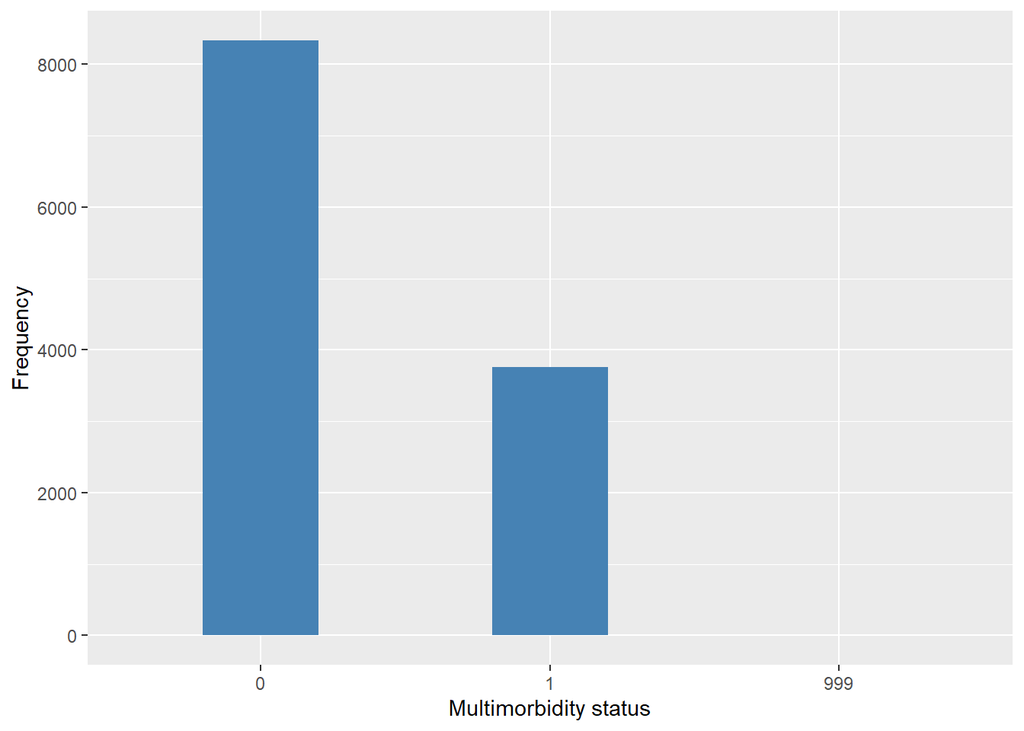

#### 2.1.1.4 Validation

### 2.1.2 Wave 2

#### 2.1.2.1 Study-specific variable description

| **Name** | `h_diabetes` | `h_asthma` | `h_hypertension` | `h_joint_disorders` | `h_cpd` | `stroke` | `mi_ha` | `h_angina` |
| --- | --- | --- | --- | --- | --- | --- | --- | --- |
| **Label** | `History of diabetes mellitus` | `History of asthma` | `History of hypertension` | `History of arthritis, rheumatism or osteoarthritis` | `History of chronic pulmonary disorders` | `Stroke` | `Myocardial infarction or heart attack` | `History of angina` |
| **Table name** | `elsa_w2_hd` | `elsa_w2_hd` | `elsa_w2_hd` | `elsa_w2_hd` | `elsa_w2_hd` | `elsa_w2_hd` | `elsa_w2_hd` | `elsa_w2_hd` |
| **Categories** | `0 = No` `1 = Yes` | `0 = No` `1 = Yes` | `0 = No` `1 = Yes` | `0 = No` `1 = Yes` | `0 = No` `1 = Yes` | `0 = No` `1 = Yes` | `0 = No` `1 = Yes` | `0 = No` `1 = Yes` |
| **Missings** | `996 = Not applicable` `997 = Refuse` `998 = Do not know` `999 = Missing` | `996 = Not applicable` `997 = Refuse` `998 = Do not know` `999 = Missing` | `996 = Not applicable` `997 = Refuse` `998 = Do not know` `999 = Missing` | `996 = Not applicable` `997 = Refuse` `998 = Do not know` `999 = Missing` | `996 = Not applicable` `997 = Refuse` `998 = Do not know` `999 = Missing` | `996 = Not applicable` `997 = Refuse` `998 = Do not know` `999 = Missing` | `996 = Not applicable` `997 = Refuse` `998 = Do not know` `999 = Missing` | `996 = Not applicable` `997 = Refuse` `998 = Do not know` `999 = Missing` |
| **Description** |  |  |  |  |  |  |  |  |

h_diabetes

| Sample size | Missing values |
| --- | --- |
| 10020 | 596 |

Category

|  | 0 | 1 |
| --- | --- | --- |
| Frequency | 8615.00 | 809.00 |
| Percentage | 85.98 | 8.07 |

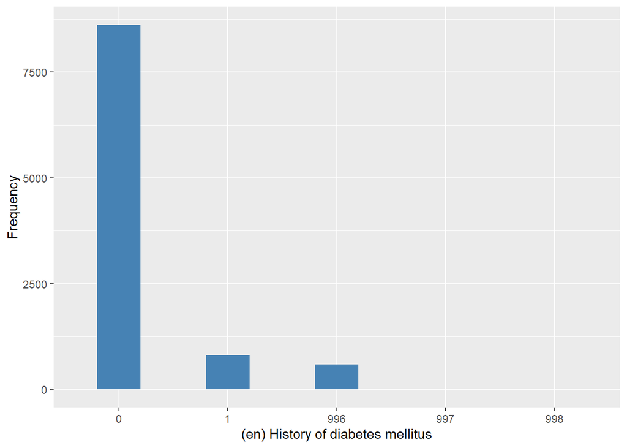

h_asthma

| Sample size | Missing values |
| --- | --- |
| 10020 | 593 |

Category

|  | 0 | 1 |
| --- | --- | --- |
| Frequency | 8215.00 | 1212.0 |
| Percentage | 81.99 | 12.1 |

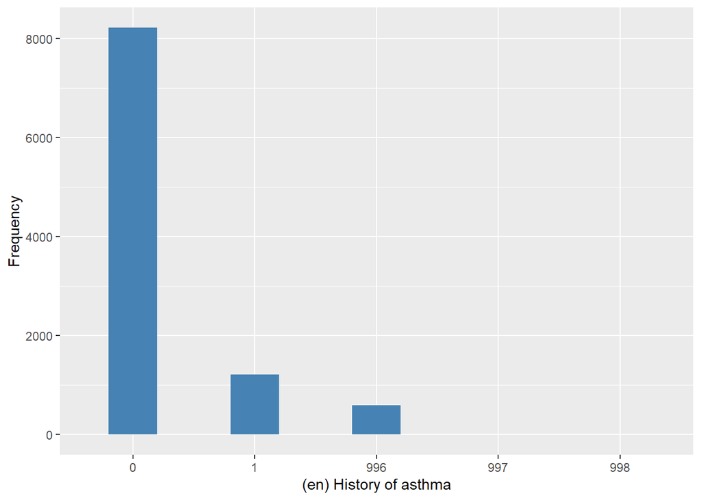

h_hypertension

| Sample size | Missing values |
| --- | --- |
| 10020 | 592 |

Category

|  | 0 | 1 |
| --- | --- | --- |
| Frequency | 5359.00 | 4069.00 |
| Percentage | 53.48 | 40.61 |

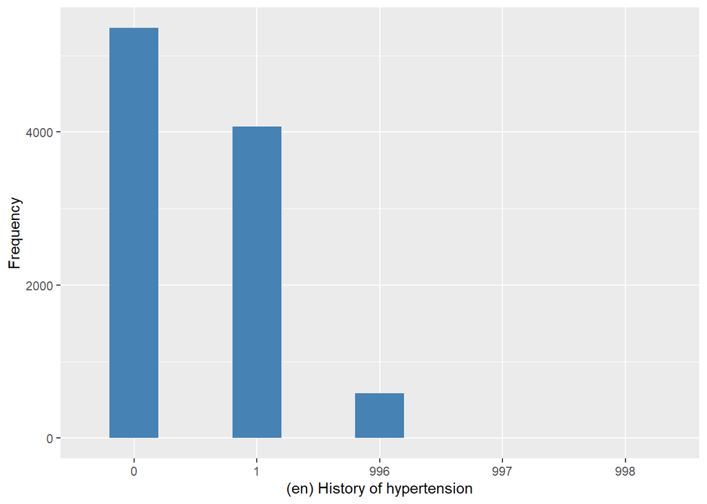

h_joint_disorders

| Sample size | Missing values |
| --- | --- |
| 10020 | 590 |

Category

|  | 0 | 1 |
| --- | --- | --- |
| Frequency | 5945.00 | 3485.00 |
| Percentage | 59.33 | 34.78 |

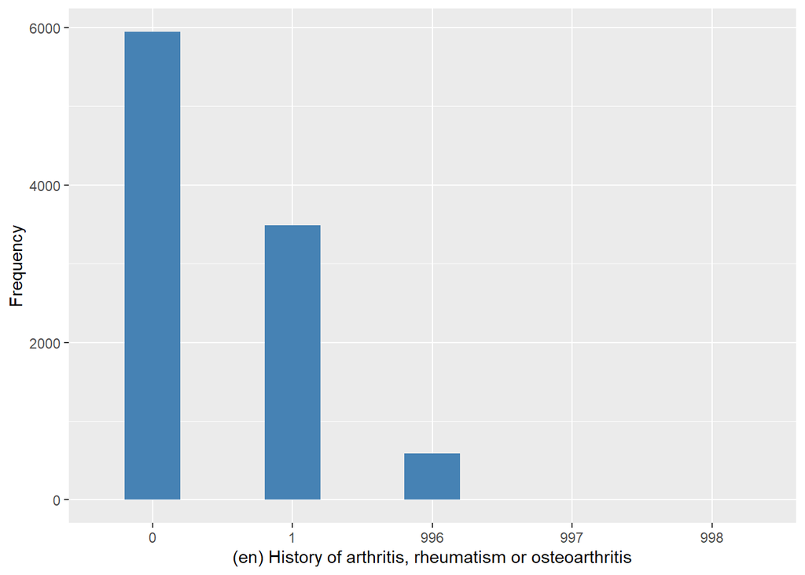

h_cpd

| Sample size | Missing values |
| --- | --- |
| 10020 | 593 |

Category

|  | 0 | 1 |
| --- | --- | --- |
| Frequency | 8738.00 | 689.00 |
| Percentage | 87.21 | 6.88 |

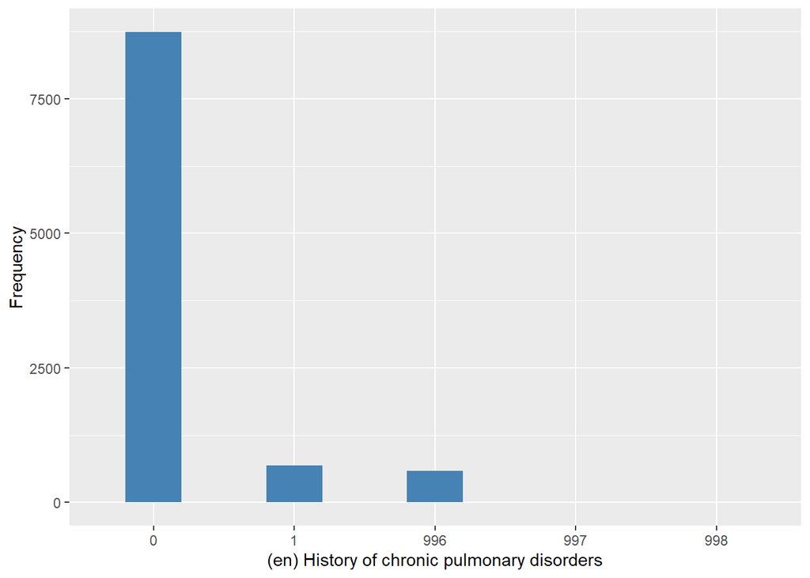

stroke

| Sample size | Missing values |
| --- | --- |
| 10020 | 597 |

Category

|  | 0 | 1 |
| --- | --- | --- |
| Frequency | 9253.00 | 170.0 |
| Percentage | 92.35 | 1.7 |

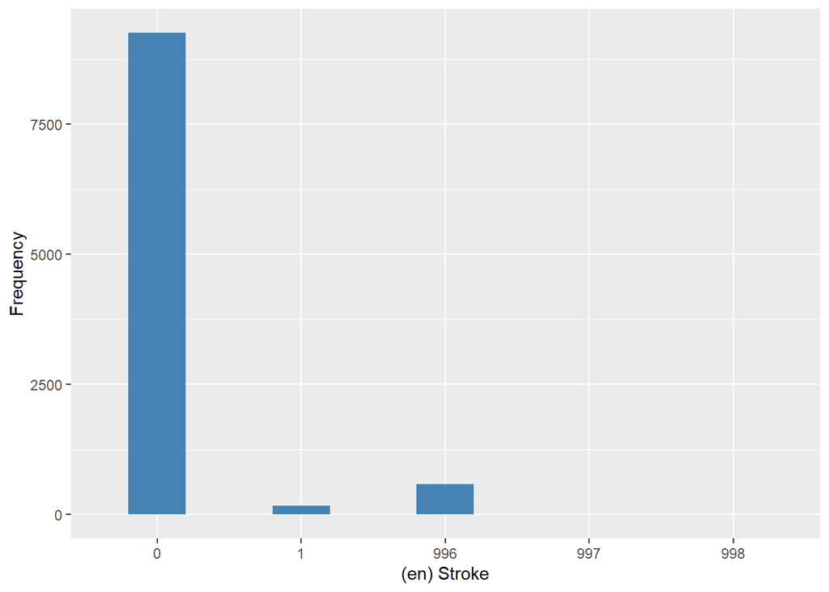

mi_ha

| Sample size | Missing values |
| --- | --- |
| 10020 | 597 |

Category

|  | 0 | 1 |
| --- | --- | --- |
| Frequency | 9291.00 | 132.00 |
| Percentage | 92.72 | 1.32 |

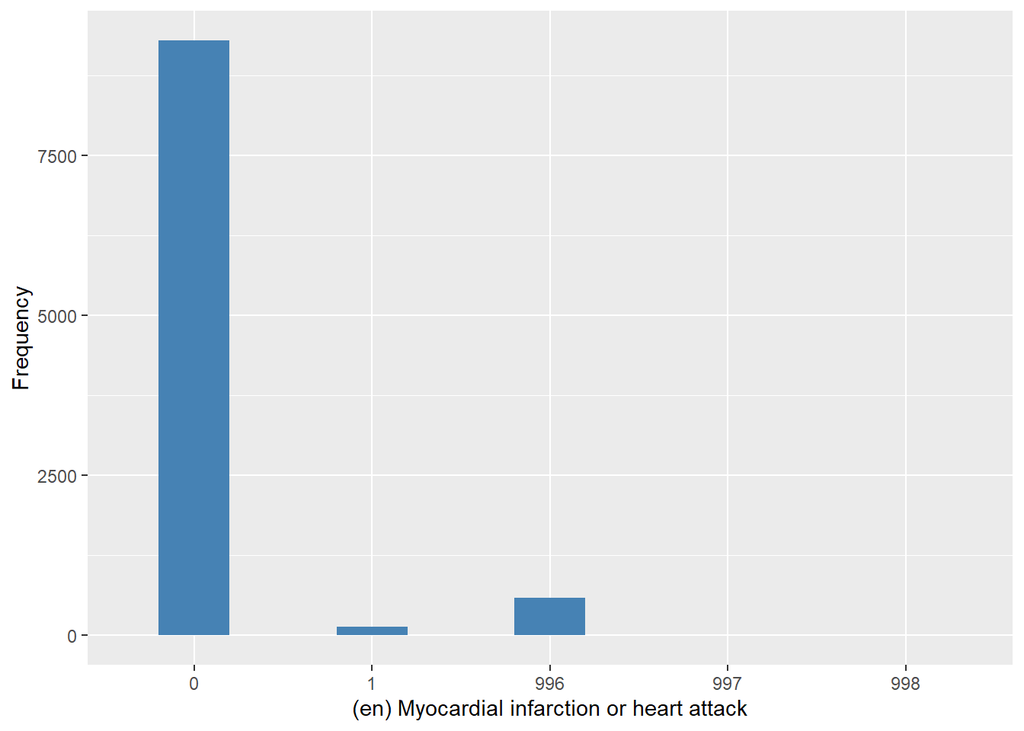

h_angina

| Sample size | Missing values |
| --- | --- |
| 10020 | 595 |

Category

|  | 0 | 1 |
| --- | --- | --- |
| Frequency | 8446.00 | 979.00 |
| Percentage | 84.29 | 9.77 |

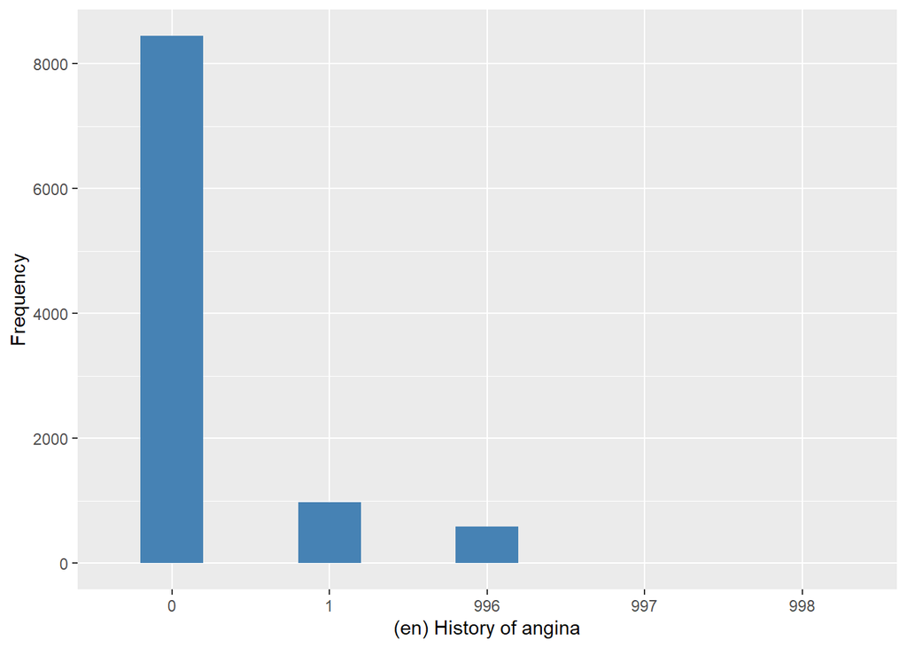

#### 2.1.2.2 Harmonisation algorithm

To compute `multimorbid` from the study-specific variables they have to be recoded as follows:

- `Multimorbid_score = sum(h_diabetes, h_asthma, h_hypertension, h_angina, mi_ha, h_joint_disorders, stroke, h_cpd)`
- `Multimorbid_status = 1 if multimorbid_score > = 2`
- `Multimorbid_status = 0 if multimorbid_score < 2`
- `otherwise into 999`

**R script:**

```r
ELSA_ds_w2 <- ELSA_w2 %>% mutate(dead = purrr::pmap(mutate_at(., vars(-id),
    `==`, 996) %>% select(., -id), all) %>% unlist()) %>% mutate_at(names(ELSA_w2[,
    -1]), ~replace(., list = which(. %in% 991:999), values = NA)) %>% mutate(multimorbid_score = rowSums(select(.,
    -1, -dead), na.rm = T)) %>% mutate(cardNA = rowSums(!is.na(select(., -1,
    -dead, -multimorbid_score)))) %>% mutate(cardNA = cardNA/cardNA) %>% mutate(multimorbid_score = multimorbid_score *
    cardNA) %>% mutate(multimorbid = case_when(multimorbid_score >= 2 ~ 1, multimorbid_score <
    2 ~ 0, dead ~ 996, TRUE ~ 999)) %>% select(id, multimorbid)
```

#### 2.1.2.3 Statistics of the new harmonized variable

Multimorbidity status

| Sample size | Missing values |
| --- | --- |
| 10020 | 589 |

Category

|  | 0 | 1 |
| --- | --- | --- |
| Frequency | 6094.00 | 3337.0 |
| Percentage | 60.82 | 33.3 |

Type of missing

|  | 991 | 992 | 993 | 994 | 995 | 996 | 997 | 998 | 999 | NA |
| --- | --- | --- | --- | --- | --- | --- | --- | --- | --- | --- |
| Frequency | 0 | 0 | 0 | 0 | 0 | 588.00 | 0 | 0 | 1.00 | 0 |
| Percentage | 0 | 0 | 0 | 0 | 0 | 5.87 | 0 | 0 | 0.01 | 0 |

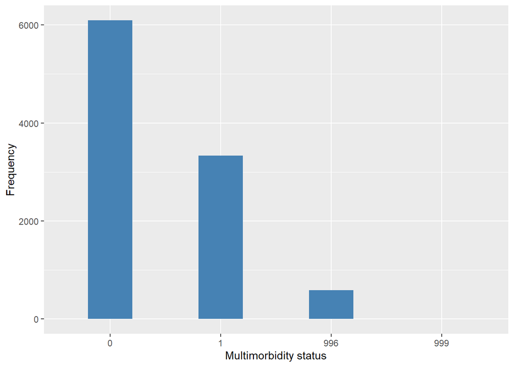

#### 2.1.2.4 Validation

### 2.1.3 Wave 3

#### 2.1.3.1 Study-specific variable description

| **Name** | `h_diabetes` | `h_asthma` | `h_hypertension` | `h_joint_disorders` | `h_cpd` | `stroke` | `mi_ha` | `h_angina` |
| --- | --- | --- | --- | --- | --- | --- | --- | --- |
| **Label** | `History of diabetes mellitus` | `History of asthma` | `History of hypertension` | `History of arthritis, rheumatism or osteoarthritis` | `History of chronic pulmonary disorders` | `Stroke` | `Myocardial infarction or heart attack` | `History of angina` |
| **Table name** | `elsa_w3_hd` | `elsa_w3_hd` | `elsa_w3_hd` | `elsa_w3_hd` | `elsa_w3_hd` | `elsa_w3_hd` | `elsa_w3_hd` | `elsa_w3_hd` |
| **Categories** | `0 = No` `1 = Yes` | `0 = No` `1 = Yes` | `0 = No` `1 = Yes` | `0 = No` `1 = Yes` | `0 = No` `1 = Yes` | `0 = No` `1 = Yes` | `0 = No` `1 = Yes` | `0 = No` `1 = Yes` |
| **Missings** | `996 = Not applicable` `997 = Refuse` `998 = Do not know` `999 = Missing` | `996 = Not applicable` `997 = Refuse` `998 = Do not know` `999 = Missing` | `996 = Not applicable` `997 = Refuse` `998 = Do not know` `999 = Missing` | `996 = Not applicable` `997 = Refuse` `998 = Do not know` `999 = Missing` | `996 = Not applicable` `997 = Refuse` `998 = Do not know` `999 = Missing` | `996 = Not applicable` `997 = Refuse` `998 = Do not know` `999 = Missing` | `996 = Not applicable` `997 = Refuse` `998 = Do not know` `999 = Missing` | `996 = Not applicable` `997 = Refuse` `998 = Do not know` `999 = Missing` |
| **Description** |  |  |  |  |  |  |  |  |

h_diabetes

| Sample size | Missing values |
| --- | --- |
| 10878 | 1112 |

Category

|  | 0 | 1 |
| --- | --- | --- |
| Frequency | 8849.00 | 917.00 |
| Percentage | 81.35 | 8.43 |

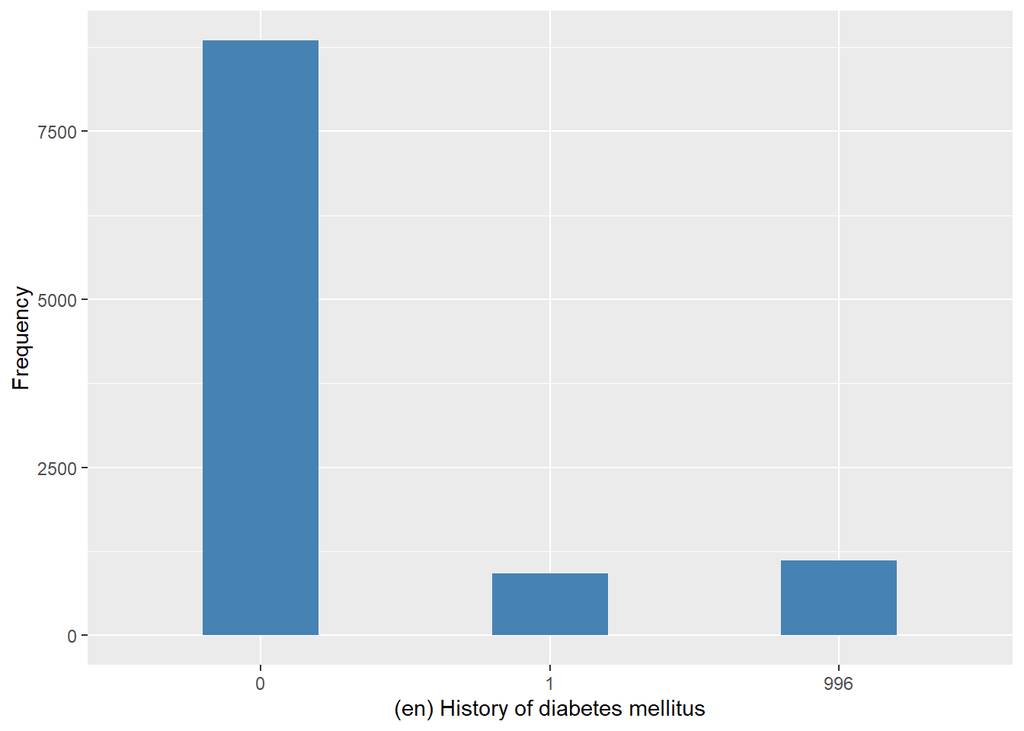

h_asthma

| Sample size | Missing values |
| --- | --- |
| 10878 | 1115 |

Category

|  | 0 | 1 |
| --- | --- | --- |
| Frequency | 8454.00 | 1309.00 |
| Percentage | 77.72 | 12.03 |

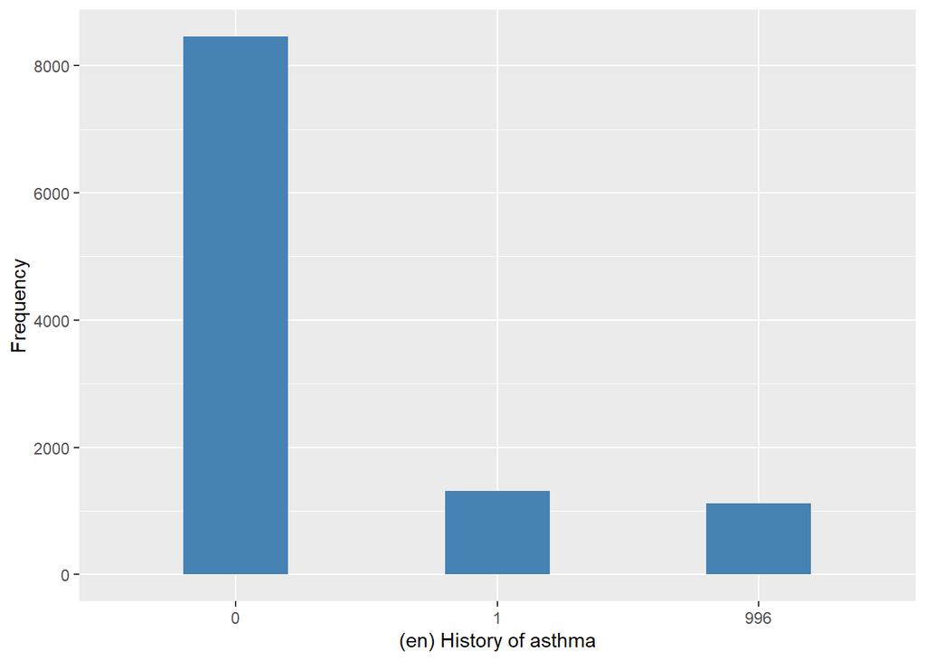

h_hypertension

| Sample size | Missing values |
| --- | --- |
| 10878 | 1108 |

Category

|  | 0 | 1 |
| --- | --- | --- |
| Frequency | 5561.00 | 4209.00 |
| Percentage | 51.12 | 38.69 |

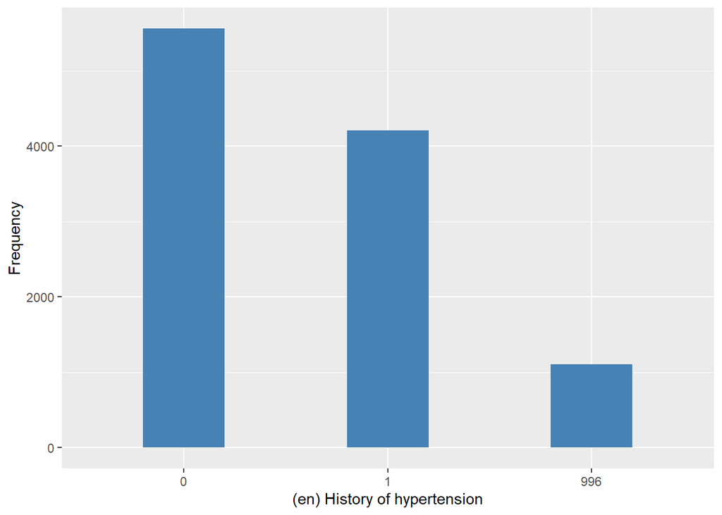

h_joint_disorders

| Sample size | Missing values |
| --- | --- |
| 10878 | 1115 |

Category

|  | 0 | 1 |
| --- | --- | --- |
| Frequency | 6187.00 | 3576.00 |
| Percentage | 56.88 | 32.87 |

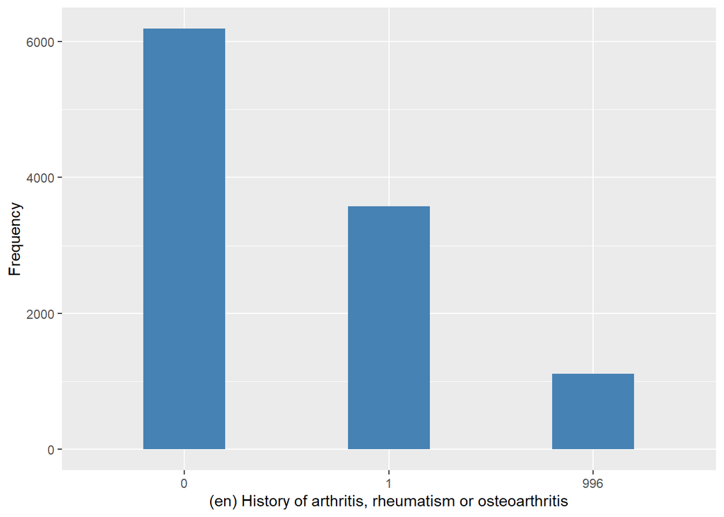

h_cpd

| Sample size | Missing values |
| --- | --- |
| 10878 | 1115 |

Category

|  | 0 | 1 |
| --- | --- | --- |
| Frequency | 9105.0 | 658.00 |
| Percentage | 83.7 | 6.05 |

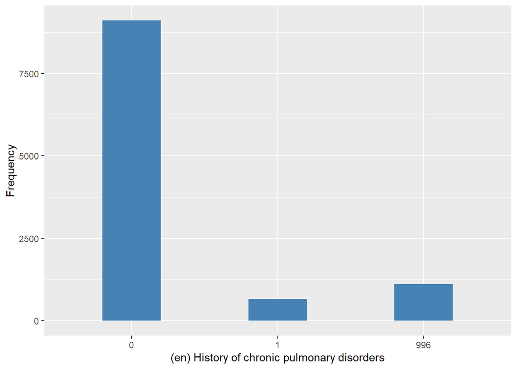

stroke

| Sample size | Missing values |
| --- | --- |
| 10878 | 1112 |

Category

|  | 0 | 1 |
| --- | --- | --- |
| Frequency | 9655.00 | 111.00 |
| Percentage | 88.76 | 1.02 |

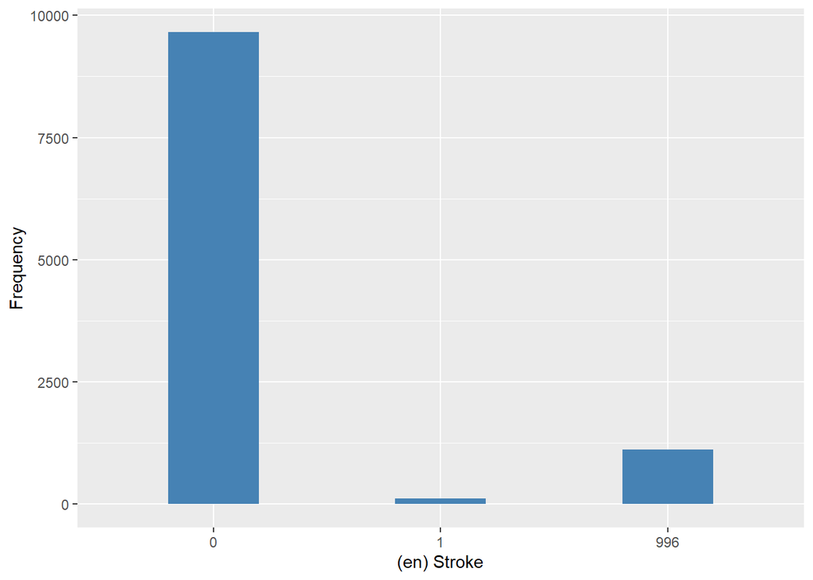

mi_ha

| Sample size | Missing values |
| --- | --- |
| 10878 | 1112 |

Category

|  | 0 | 1 |
| --- | --- | --- |
| Frequency | 9655.00 | 111.00 |
| Percentage | 88.76 | 1.02 |

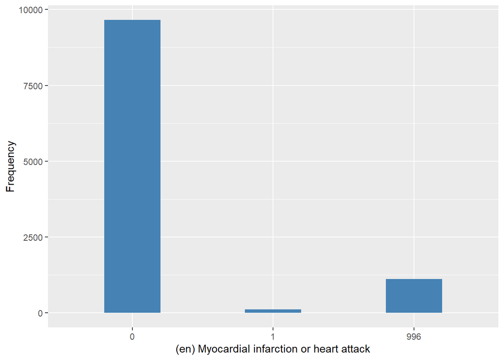

h_angina

| Sample size | Missing values |
| --- | --- |
| 10878 | 1112 |

Category

|  | 0 | 1 |
| --- | --- | --- |
| Frequency | 8859.00 | 907.00 |
| Percentage | 81.44 | 8.34 |

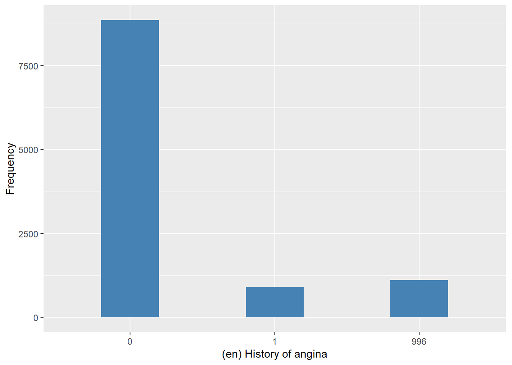

#### 2.1.3.2 Harmonisation algorithm

To compute `multimorbid` from the study-specific variables they have to be recoded as follows:

- `Multimorbid_score = sum(h_diabetes, h_asthma, h_hypertension, h_angina, mi_ha, h_joint_disorders, stroke, h_cpd)`
- `Multimorbid_status = 1 if multimorbid_score > = 2`
- `Multimorbid_status = 0 if multimorbid_score < 2`
- `otherwise into 999`

**R script:**

```r
ELSA_ds_w3 <- ELSA_w3 %>% mutate(dead = purrr::pmap(mutate_at(., vars(-id),
    `==`, 996) %>% select(., -id), all) %>% unlist()) %>% mutate_at(names(ELSA_w3[,
    -1]), ~replace(., list = which(. %in% 991:999), values = NA)) %>% mutate(multimorbid_score = rowSums(select(.,
    -1, -dead), na.rm = T)) %>% mutate(cardNA = rowSums(!is.na(select(., -1,
    -dead, -multimorbid_score)))) %>% mutate(cardNA = cardNA/cardNA) %>% mutate(multimorbid_score = multimorbid_score *
    cardNA) %>% mutate(multimorbid = case_when(multimorbid_score >= 2 ~ 1, multimorbid_score <
    2 ~ 0, dead ~ 996, TRUE ~ 999)) %>% select(id, multimorbid)
```

#### 2.1.3.3 Statistics of the new harmonized variable

Multimorbidity status

| Sample size | Missing values |
| --- | --- |
| 10878 | 1108 |

Category

|  | 0 | 1 |
| --- | --- | --- |
| Frequency | 6372.00 | 3398.00 |
| Percentage | 58.58 | 31.24 |

Type of missing

|  | 991 | 992 | 993 | 994 | 995 | 996 | 997 | 998 | 999 | NA |
| --- | --- | --- | --- | --- | --- | --- | --- | --- | --- | --- |
| Frequency | 0 | 0 | 0 | 0 | 0 | 1108.00 | 0 | 0 | 0 | 0 |
| Percentage | 0 | 0 | 0 | 0 | 0 | 10.19 | 0 | 0 | 0 | 0 |

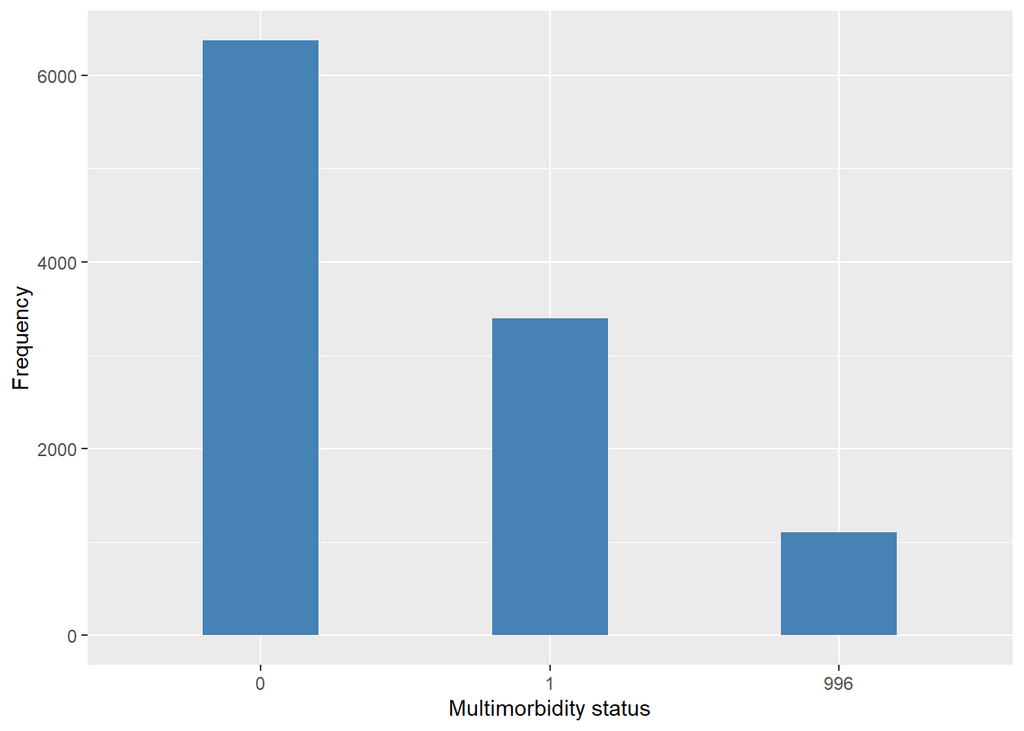

#### 2.1.3.4 Validation

### 2.1.4 Wave 4

#### 2.1.4.1 Study-specific variable description

| **Name** | `h_diabetes` | `h_asthma` | `h_hypertension` | `h_joint_disorders` | `h_cpd` | `stroke` | `mi_ha` | `h_angina` |
| --- | --- | --- | --- | --- | --- | --- | --- | --- |
| **Label** | `History of diabetes mellitus` | `History of asthma` | `History of hypertension` | `History of arthritis, rheumatism or osteoarthritis` | `History of chronic pulmonary disorders` | `Stroke` | `Myocardial infarction or heart attack` | `History of angina` |
| **Table name** | `elsa_w4_hd` | `elsa_w4_hd` | `elsa_w4_hd` | `elsa_w4_hd` | `elsa_w4_hd` | `elsa_w4_hd` | `elsa_w4_hd` | `elsa_w4_hd` |
| **Categories** | `0 = No` `1 = Yes` | `0 = No` `1 = Yes` | `0 = No` `1 = Yes` | `0 = No` `1 = Yes` | `0 = No` `1 = Yes` | `0 = No` `1 = Yes` | `0 = No` `1 = Yes` | `0 = No` `1 = Yes` |
| **Missings** | `996 = Not applicable` `997 = Refuse` `998 = Do not know` `999 = Missing` | `996 = Not applicable` `997 = Refuse` `998 = Do not know` `999 = Missing` | `996 = Not applicable` `997 = Refuse` `998 = Do not know` `999 = Missing` | `996 = Not applicable` `997 = Refuse` `998 = Do not know` `999 = Missing` | `996 = Not applicable` `997 = Refuse` `998 = Do not know` `999 = Missing` | `996 = Not applicable` `997 = Refuse` `998 = Do not know` `999 = Missing` | `996 = Not applicable` `997 = Refuse` `998 = Do not know` `999 = Missing` | `996 = Not applicable` `997 = Refuse` `998 = Do not know` `999 = Missing` |
| **Description** |  |  |  |  |  |  |  |  |

h_diabetes

| Sample size | Missing values |
| --- | --- |
| 12731 | 1697 |

Category

|  | 0 | 1 |
| --- | --- | --- |
| Frequency | 9939.00 | 1095.0 |
| Percentage | 78.07 | 8.6 |

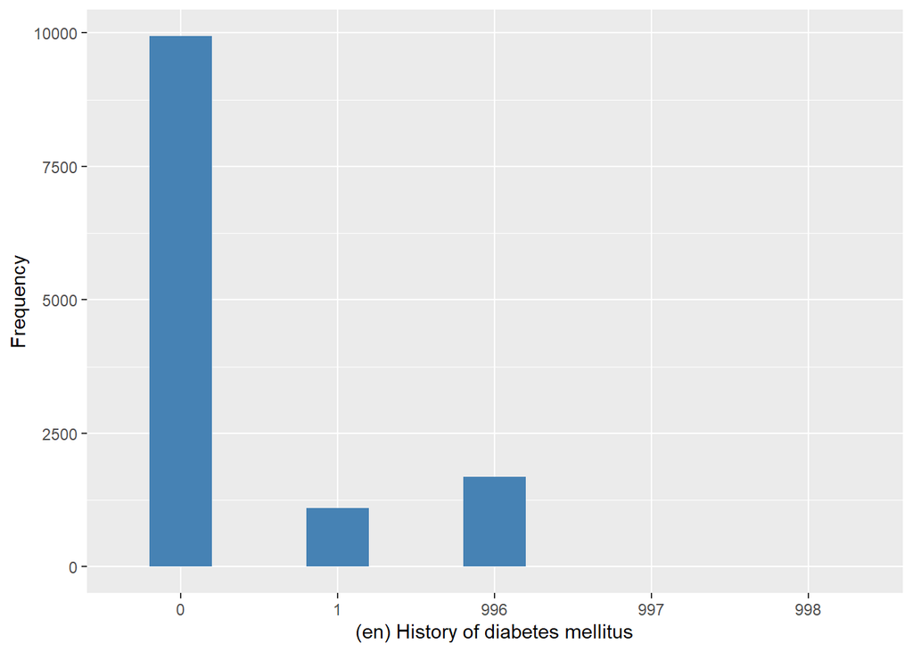

h_asthma

| Sample size | Missing values |
| --- | --- |
| 12731 | 1694 |

Category

|  | 0 | 1 |
| --- | --- | --- |
| Frequency | 9550.00 | 1487.00 |
| Percentage | 75.01 | 11.68 |

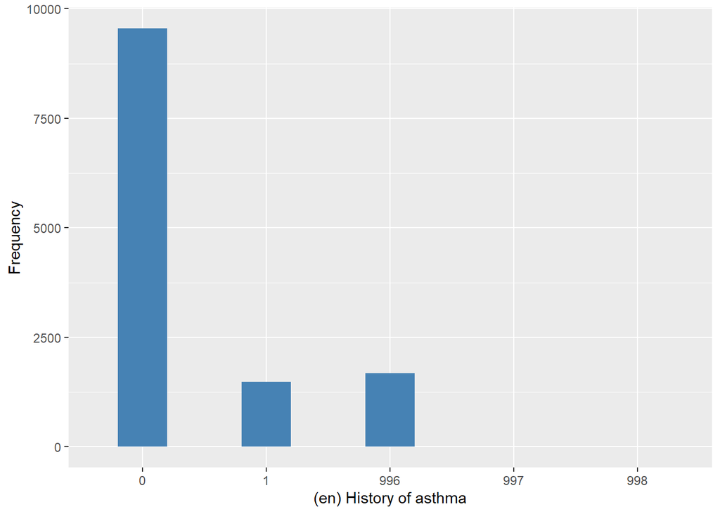

h_hypertension

| Sample size | Missing values |
| --- | --- |
| 12731 | 1694 |

Category

|  | 0 | 1 |
| --- | --- | --- |
| Frequency | 6368.00 | 4669.00 |
| Percentage | 50.02 | 36.67 |

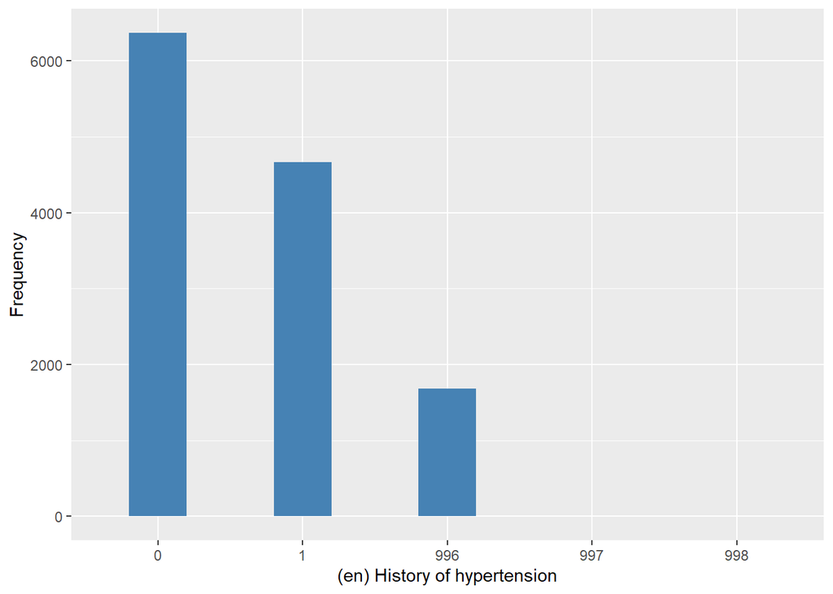

h_joint_disorders

| Sample size | Missing values |
| --- | --- |
| 12731 | 1694 |

Category

|  | 0 | 1 |
| --- | --- | --- |
| Frequency | 6941.00 | 4096.00 |
| Percentage | 54.52 | 32.17 |

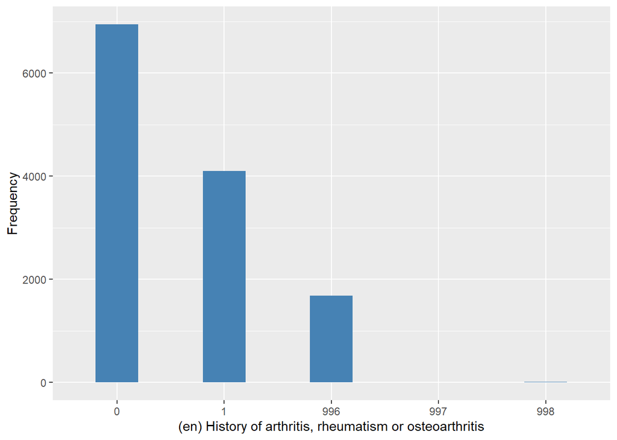

h_cpd

| Sample size | Missing values |
| --- | --- |
| 12731 | 1696 |

Category

|  | 0 | 1 |
| --- | --- | --- |
| Frequency | 10309.00 | 726.0 |
| Percentage | 80.98 | 5.7 |